# Authors

**Group No. 124**

Achintya Gupta (s3806436@student.rmit.edu.au)

Paras Kathayat (s3805876@student.rmit.edu.au)

# Introduction

## Data Source

**Data Collected From**

Dr. Aksakalli, V.(2020,September 15).*"Diabetes.csv": Early stage diabetes risk prediction dataset from `UCI`*. https://github.com/vaksakalli/datasets/blob/master/diabetes.csv

**Original Data Source**

UCI Machine Learning Repository.(2020,August 12).*"Early stage diabetes risk prediction dataset"*. https://archive.ics.uci.edu/ml/datasets/Early+stage+diabetes+risk+prediction+dataset.

## Dataset Details

The dataset has been collected by M M Faniqul Islam, Rahatara Ferdousi, Yasmin Bushra, Sadikur Rahman and Humayrausing through direct questionnaires from the patients of Sylhet Diabetes Hospital in Sylhet, Bangladesh and approved by a doctor.

This dataset contains the sign and symptom data of newly diabetic or would be diabetic patient. Following is the list of attributes present in the dataset:

1. **Age** - Range (20-65) years - Type : Integer
2. **Gender** - 1. Male, 2.Female - Type : Object
3. **Polyuria** - 1.Yes, 2.No. - Type : Object
4. **Polydipsia** - 1.Yes, 2.No. - Type : Object
5. **sudden weight loss** - 1.Yes, 2.No. - Type : Object
6. **weakness** - 1.Yes, 2.No. - Type : Object
7. **Polyphagia** - 1.Yes, 2.No. - Type : Object
8. **Genital thrush** - 1.Yes, 2.No. - Type : Object
9. **visual blurring** - 1.Yes, 2.No. - Type : Object
10. **Itching** - 1.Yes, 2.No. - Type : Object
11. **Irritability** - 1.Yes, 2.No. - Type : Object
12. **delayed healing** - 1.Yes, 2.No. - Type : Object
13. **partial paresis** - 1.Yes, 2.No. - Type : Object
14. **muscle stiffness** - 1.Yes, 2.No. - Type : Object
15. **Alopecia** - 1.Yes, 2.No. - Type : Object
16. **Obesity** - 1.Yes, 2.No. - Type : Object
17. **class** - 1.Positive, 2.Negative.

## Dataset Features

Dataset features to be included in the project are as follows:

| Name | Data Type | Units | Brief Description |
| --- | --- | --- | --- |
| Age | Integer | Years | Age of patient at the time of data collection. |
| Gender | Object | Not Applicable | Gender of the patient |
| Polyuria | Object | Unknown | Condition where the body urinates more than usual. |
| Polydipsia | Object | Unknown | Condition causing excess thirst or excess drinking. |
| sudden weight loss | Object | Unknown | Patients observed sudden loss in their body weight. |
| weakness | Object | Unknown | Patients experienced weakness in their body. |
| Polyphagia | Object | Unknown | Condition causing excessive eating or appetite. |
| Genital thrush | Object | Unknown | Condition caused by a type of yeast called Candida. |
| visual blurring | Object | Unknown | Patients experienced blurring of their vision. |
| Itching | Object | Unknown | An uncomfortable sensation on the skin forcing to scratch. |
| Irritability | Object | Unknown | Patients experienced tendency to be easily annoyed. |
| delayed healing | Object | Unknown | Patients experienced delayed healing of wounds. |
| partial paresis | Object | Unknown | Condition involves weakening of muscle or muscle group. |
| muscle stiffness | Object | Unknown | Patients experienced muscle soreness in their body. |
| Alopecia | Object | Unknown | Partial or complete absence of hair from where it normally grows. |
| Obesity | Object | Unknown | Condition of being extremely fat or overweight. |
| class | Object | Unknown | Result if the patient is diabetic or not. |

## Target Feature

The response(target) feature will be **`class`** attribute. The class attribute represents the result of diabetic test(positive or negative). We will build a predictive model that would predict based on the selected features if a person would be diabetic or not.

# Goals and Objectives

Diabetes is a disease that occurs when your blood glucose, also called blood sugar, is too high. Over time, having too much glucose in your blood can cause health problems, such as heart disease, nerve damage, eye problems, and kidney disease. You can take steps to prevent diabetes or manage it.[1]

About 422 million people worldwide have diabetes, the majority living in low-and middle-income countries, and 1.6 million deaths are directly attributed to diabetes each year. Both the number of cases and the prevalence of diabetes have been steadily increasing over the past few decades.[2]

The objective here is to identify features that are most significant in detecting early stages of diabetes. Diabetes symptoms are so mild that they are hard to spot it at first.[3] This analysis will not only explore the significance of the factors but also predict if a person is classified as a diabetic or not. This analysis will be able to spread awareness among people so that early detection and relevant actions could be taken so as to reduce further damage of diabetes on the body.

# Data Cleaning and Preprocessing

Loading the dataset from Dr. Vural Aksakalli's Github account.

```python
import numpy as np
import pandas as pd
import seaborn as sns
import matplotlib.pyplot as plt
import io
import requests

import warnings
warnings.filterwarnings("ignore")

import os, ssl
if (not os.environ.get('PYTHONHTTPSVERIFY', '') and
    getattr(ssl, '_create_unverified_context', None)):
    ssl._create_default_https_context = ssl._create_unverified_context

dataset_url = 'https://raw.githubusercontent.com/vaksakalli/datasets/master/diabetes.csv'
url_content = requests.get(dataset_url).content
df = pd.read_csv(io.StringIO(url_content.decode('utf-8')))
```

Once we successfully load the data into the notebook, we will check the shape of the data.

```python
# checking the shape of dataset.
print(f'Total number of rows: {df.shape[0]}')
print(f'Total number of columns: {df.shape[1]}')
```

```
Total number of rows: 520
Total number of columns: 17
```

Now that we have the shape of data, its time to have a look at the data using `.head()` function.

```python
df.head()
```

|  | Age | Gender | Polyuria | Polydipsia | sudden weight loss | weakness | Polyphagia | Genital thrush | visual blurring | Itching | Irritability | delayed healing | partial paresis | muscle stiffness | Alopecia | Obesity | class |
| --- | --- | --- | --- | --- | --- | --- | --- | --- | --- | --- | --- | --- | --- | --- | --- | --- | --- |
| 0 | 40 | Male | No | Yes | No | Yes | No | No | No | Yes | No | Yes | No | Yes | Yes | Yes | Positive |
| 1 | 58 | Male | No | No | No | Yes | No | No | Yes | No | No | No | Yes | No | Yes | No | Positive |
| 2 | 41 | Male | Yes | No | No | Yes | Yes | No | No | Yes | No | Yes | No | Yes | Yes | No | Positive |
| 3 | 45 | Male | No | No | Yes | Yes | Yes | Yes | No | Yes | No | Yes | No | No | No | No | Positive |
| 4 | 60 | Male | Yes | Yes | Yes | Yes | Yes | No | Yes | Yes | Yes | Yes | Yes | Yes | Yes | Yes | Positive |

Looking at the dataset, we observe that there are no **unnecessary columns** to drop from the dataset. Therefore we move on to checking the **null values** in the dataset.

```python
#checking for null values
df.isna().sum()
```

```
Age                   0
Gender                0
Polyuria              0
Polydipsia            0
sudden weight loss    0
weakness              0
Polyphagia            0
Genital thrush        0
visual blurring       0
Itching               0
Irritability          0
delayed healing       0
partial paresis       0
muscle stiffness      0
Alopecia              0
Obesity               0
class                 0
dtype: int64
```

Clearly, there is no null values present in the dataset. Now checking the **data types** of the attributes.

```python
df.dtypes
```

```
Age                    int64
Gender                object
Polyuria              object
Polydipsia            object
sudden weight loss    object
weakness              object
Polyphagia            object
Genital thrush        object
visual blurring       object
Itching               object
Irritability          object
delayed healing       object
partial paresis       object
muscle stiffness      object
Alopecia              object
Obesity               object
class                 object
dtype: object
```

For checking **outliers and performing sanity check** on Age attribute, we need to check for the summary statistics of the attribute using `.describe()` method.

```python
# checking for outliers in Age attribute.
df['Age'].describe()
```

```
count    520.000000
mean      48.028846
std       12.151466
min       16.000000
25%       39.000000
50%       47.500000
75%       57.000000
max       90.000000
Name: Age, dtype: float64
```

According to the attribute information from the data source, the age values should range from `20-65 years`. Therefore we will remove the outlier values.

```python
# sanity check for Age values and removing values out the range 20-65 years.
df = df[(df['Age']>= 20) & (df['Age']<= 65)]
df['Age'].describe()
```

```
count    468.000000
mean      45.677350
std        9.951303
min       25.000000
25%       38.000000
50%       46.000000
75%       54.000000
max       65.000000
Name: Age, dtype: float64
```

Now, that we have removed the outlier values from data, lets check unique values in each dataset to look for any undesired values among attributes.

```python
#checking for unique values in each attribute.
colNames = df.columns.tolist()
for name in colNames:
    print(f'{df[name].value_counts()}')
```

```
35    30
48    28
43    25
30    25
40    24
55    22
47    21
38    20
53    20
50    18
45    18
58    18
54    16
39    16
57    15
60    15
28     9
42     9
61     8
36     8
46     8
56     8
44     7
62     7
49     7
37     7
27     6
34     6
65     6
64     5
51     5
32     5
41     4
33     4
52     4
59     4
31     3
63     3
25     2
29     1
```

[output cut: 35 more lines]

```
No     277
Yes    191
Name: partial paresis, dtype: int64
No     307
Yes    161
Name: muscle stiffness, dtype: int64
No     319
Yes    149
Name: Alopecia, dtype: int64
No     389
Yes     79
Name: Obesity, dtype: int64
Positive    284
Negative    184
Name: class, dtype: int64
```

Clearly, there is no incorrect values in any attribute and no **irregular cardinality**. Hence, we can say that the dataset is already clean and ready for the **Exploration and Visualization**.

# Data Exploration and Visualization

## Exploring Single Variables

Ploting pie charts for few attributes to explore the distribution of data in the dataset.

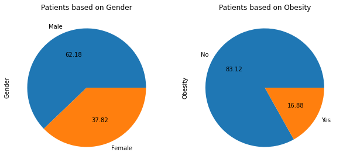

```python
plt.figure(figsize= (10,5))

# plot to represent the distribution of patients based on their gender.
plt.subplot(1,2,1);df['Gender'].value_counts().plot(kind = 'pie' , autopct='%.2f');
plt.title("Patients based on Gender")

# plot to represent the distribution of patients based on their obesity condition.
plt.subplot(1,2,2);df['Obesity'].value_counts().plot(kind = 'pie' , autopct='%.2f');
plt.title("Patients based on Obesity")
```

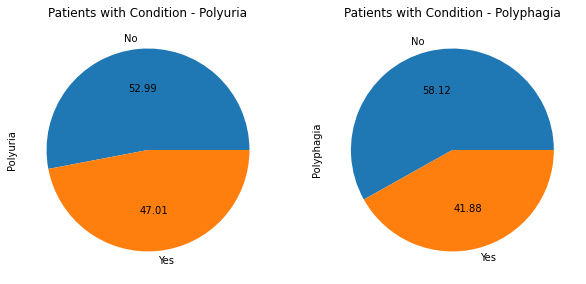

```python
plt.figure(figsize= (10,5))

# plot to represent the distribution of patients based on their Polyuria condition.
plt.subplot(1,2,1);df['Polyuria'].value_counts().plot(kind = 'pie' , autopct='%.2f');
plt.title("Patients with Condition - Polyuria")

# plot to represent the distribution of patients based on their Polyphagia condition.
plt.subplot(1,2,2);df['Polyphagia'].value_counts().plot(kind = 'pie' , autopct='%.2f');
plt.title("Patients with Condition - Polyphagia")
```

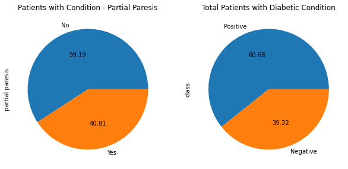

```python
plt.figure(figsize= (10,5))

# plot to represent the distribution of patients based on their Partial Paresis condition.
plt.subplot(1,2,1);df['partial paresis'].value_counts().plot(kind = 'pie' , autopct='%.2f');
plt.title("Patients with Condition - Partial Paresis")

# plot to represent the distribution of patients having diabetes or not.
plt.subplot(1,2,2);df['class'].value_counts().plot(kind = 'pie' , autopct='%.2f');
plt.title("Total Patients with Diabetic Condition")
```

## Exploring Two Variables

Creating barplot that depicts the total number of patients based on their gender and their diabetic status.

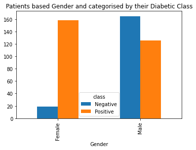

```python
# grouping data for patients based on their gender and diabetic class.
byGender = df.groupby("Gender")["class"].value_counts()

# creating a barplot.
byGender.unstack().plot(kind= 'bar');
plt.title("Patients based Gender and categorised by their Diabetic Class")
```

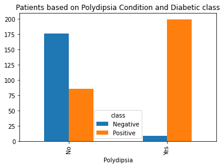

```python
# grouping data for patients based on their polydipsia condition and diabetic class.
byPolydipsia = df.groupby("Polydipsia")["class"].value_counts()

# creating a barplot.
byPolydipsia.unstack().plot(kind= 'bar');
plt.title("Patients based on Polydipsia Condition and Diabetic class")
```

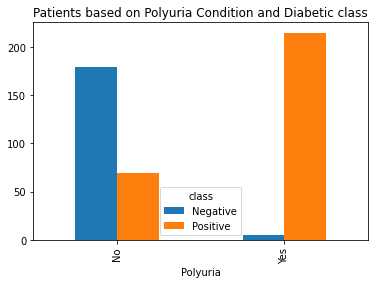

```python
# grouping data for patients based on their polyuria condition and diabetic class.
byPolyuria = df.groupby("Polyuria")["class"].value_counts()

# creating a barplot.
byPolyuria.unstack().plot(kind= 'bar');
plt.title("Patients based on Polyuria Condition and Diabetic class")
```

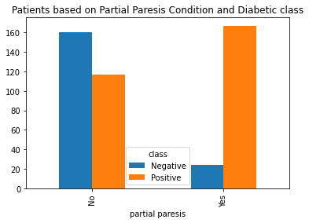

```python
# grouping data for patients based on their partial paresis condition and diabetic class.
byParesis = df.groupby("partial paresis")["class"].value_counts()

# creating a barplot.
byParesis.unstack().plot(kind= 'bar');
plt.title("Patients based on Partial Paresis Condition and Diabetic class")
```

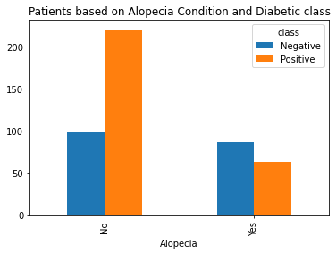

```python
# grouping data for patients based on their Alopecia condition and diabetic class.
byAlopecia = df.groupby("Alopecia")["class"].value_counts()

# creating a barplot.
byAlopecia.unstack().plot(kind= 'bar');
plt.title("Patients based on Alopecia Condition and Diabetic class")
```

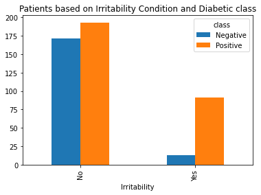

```python
# grouping data for patients based on their Irritability condition and diabetic class.
byIrr = df.groupby("Irritability")["class"].value_counts()

# creating a barplot.
byIrr.unstack().plot(kind= 'bar');
plt.title("Patients based on Irritability Condition and Diabetic class")
```

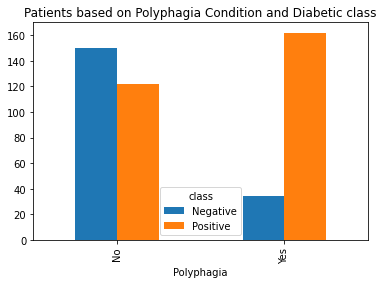

```python
# grouping data for patients based on their Polyphagia condition and diabetic class.
byPolyphagia = df.groupby("Polyphagia")["class"].value_counts()

# creating a barplot.
byPolyphagia.unstack().plot(kind= 'bar');
plt.title("Patients based on Polyphagia Condition and Diabetic class")
```

## Exploring Three Variables.

Creating a new 'AgeGroup' attribute in the dataset.

```python
# creating age groups from age column.
bins = [20, 30, 50, 65]
labels = ['20-29', '30-49', '50-65']
df['AgeGroup'] = pd.cut(df.Age, bins, labels = labels, include_lowest = True)
```

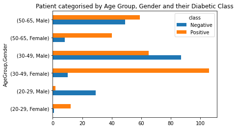

```python
# grouping data for patients based on their Age Group, Gender and their diabetic class.
byAge = df.groupby(['AgeGroup', 'Gender'])['class'].value_counts()

bins = [20, 30, 50, 65]
labels = ['20-29', '30-49', '50-65']
df['AgeGroup'] = pd.cut(df['Age'], bins, labels= labels, include_lowest = True)

# creating horizontal barplot.
byAge.unstack().plot(kind= 'barh');
plt.title("Patient categorised by Age Group, Gender and their Diabetic Class")
```

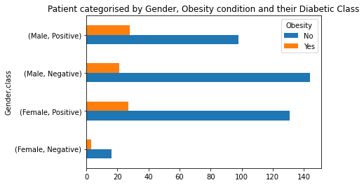

```python
# grouping data for patients based on their Gender, Obesity Condition and their diabetic class.
obese = df.groupby(["Gender","class"])["Obesity"].value_counts()

# creating horizontal barplot.
obese.unstack().plot(kind= 'barh');
plt.title("Patient categorised by Gender, Obesity condition and their Diabetic Class")
```

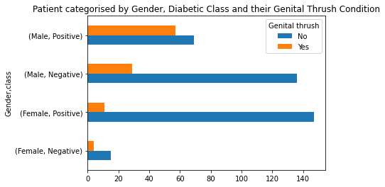

```python
# grouping data for patients based on their Gender, diabetic class and their  status.
genital = df.groupby(["Gender","class"])["Genital thrush"].value_counts()

# creating horizontal barplot.
genital.unstack().plot(kind= 'barh');
plt.title("Patient categorised by Gender, Diabetic Class and their Genital Thrush Condition")
```

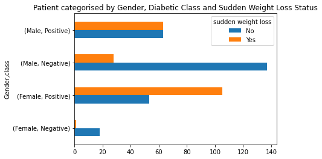

```python
# grouping data for patients based on their Gender, diabetic class and their sudden weight loss status.
swl = df.groupby(["Gender","class"])["sudden weight loss"].value_counts()

# creating horizontal barplot.
swl.unstack().plot(kind= 'barh');
plt.title("Patient categorised by Gender, Diabetic Class and Sudden Weight Loss Status")
```

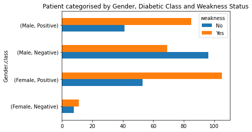

```python
# grouping data for patients based on their Gender, diabetic class and their weakness status.
weak = df.groupby(["Gender","class"])["weakness"].value_counts()

# creating horizontal barplot.
weak.unstack().plot(kind= 'barh');
plt.title("Patient categorised by Gender, Diabetic Class and Weakness Status")
```

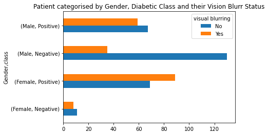

```python
# grouping data for patients based on their Gender, diabetic class and their vision blurr status.
vblurr = df.groupby(["Gender","class"])["visual blurring"].value_counts()

# creating horizontal barplot.
vblurr.unstack().plot(kind= 'barh');
plt.title("Patient categorised by Gender, Diabetic Class and their Vision Blurr Status")
```

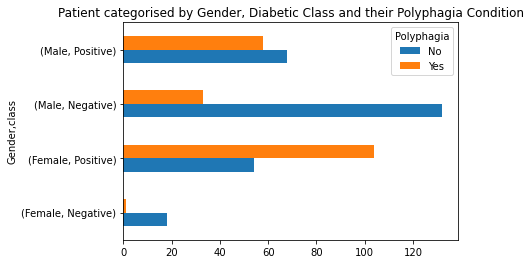

```python
# grouping data for patients based on their Gender, diabetic class and their Polyphagia status.
polypha = df.groupby(["Gender","class"])["Polyphagia"].value_counts()

# creating horizontal barplot.
polypha.unstack().plot(kind= 'barh');
plt.title("Patient categorised by Gender, Diabetic Class and their Polyphagia Condition")
```

# Summary & Conclusions

After data exploration, we can observe that a most of the patients, around `62.18%` are **male** and only `37.82%` are **female**. Around `60.68%` of patients have been diagnosed with **diabetes**.

Looking at the bar charts we can observe that a significant number of female patients have been diagnosed `positive` for diabetes whereas a relatively less number of male patients have been diagnosed `positive`. Moreover, there are more male patients who have diagnosed `negative` for diabetes and that clearly represents that **female patients are susceptible to diabetes**.

After categorizing patients based on their gender and age group, we observed that female from age group `30-49` years are **highly susceptible** to diabetes followed by those female patients who are in their late `50-65` years. However, for male patients, no such pattern detected for diabetic condition as a large number of male patients have been diagnosed `negative` for the age group `20-29` and `30-49` years.

Among the patients diagnosed `positive`, female patients have a higher tendency of having **Polyphagia** as compared to male patients.

# References

[1] National Institute of Diabetes and Digestive and Kidney Diseases.(2021,April 10).*Health Topic-"Diabetes".* https://www.niddk.nih.gov/health-information/diabetes

[2] World Health Organisation.(2021,April 10).*Health Topic- "Diabetes".* https://www.who.int/health-topics/diabetes#tab=tab_1

[3] healthline.(2020).*"Everything you need to know about Diabetes".* https://www.healthline.com/health/diabetes#symptoms